# BIOSTAT 24-Project

Annie Oh

March 7, 2020

## Introduction

Tobacco smoke is the most common environmental risk factor for chronic obstructive pulmonary disease (COPD). Part of the relationship between tobacco smoke and development of COPD may be related to the toxins in tobacco, which leads to a pro-inflammatory state in individuals. This inflammation leads to airway mucus hypersecretion, bronchial wall thickening, and bronchoconstriction. Biomarkers of inflammation are increased in current and former smokers, and may be increased in those with a higher previous smoking-pack year history and those with poorer lung function based off spirometry. The identification of inflammatory biomarkers that are related to smokers may lead to early disease prediction and monitoring in the future.

# What we know

There are current proposed biological makers of COPD which include sputum mucin concentration and plasma fibrinogen, C-reactive protein (CRP), and soluble tumor-necrosis factor (TNF) receptors (sTNFRSF)1A (also known as sTNF-R55), and (sTNFRSF)1B (also known as sTNF-R75). Total sputum mucin concentrations are higher in current or former smokers with COPD, and also in those with more respiratory exacerbations. Elevated plasma fibrinogen has been associated with reduced FEV1, are higher in patients with COPD, and are associated with disease severity and exacerbations. An elevated CRP in smokers has been associated with reduction in FEV1, and is also associated with worse respiratory symptoms measured by CAT scores and chronic bronchitis in SPIROMICS smokers with preserved spirometry. TNF can bind to two receptors, TNF receptor 1 and TNF receptor type 2. Soluble TNF receptors can either inhibit or promote the activity of TNF??, however they serve as sensitive and reliable markers of TNF-?? activity and are considered a pro-inflammatory marker. sTNF-R55 and sTNF-R75 is elevated in those with stable COPD, and are also elevated in those with exacerbations. sTNF-R55 is associated with increased symptom burden measured by CAT scores in SPIROMICS smokers with preserved spirometry.

# Why we care

The identification of inflammatory biomarkers that are related to smokers may lead to early disease prediction and monitoring in the future. Using these biomarkers identified above, and the relationship to smoking-pack year history and lung function may help identify those who may be prone to continued worsening of COPD.

## Methods

```r
library(rtemis)
#Read in data
setwd("C:/Users/aoh/Dropbox/TICR/BIOSTAT 214_Advanced R/Final Project")
RS<-read.csv('Biostat 214 data.csv')
#Check data
dim(RS)
```

```
## [1] 2973  474
```

```r
str(RS)
```

```
## 'data.frame':    2973 obs. of  474 variables:
##  $ subjid                       : Factor w/ 2973 levels "CU100010","CU100023",..: 1 2 3 4 5 6 7 8 9 10 ...
##  $ site                         : Factor w/ 13 levels "CU","IA","JH",..: 1 1 1 1 1 1 1 1 1 1 ...
##  $ bmi_cm_v1                    : num  26.6 28.4 29.4 37.5 31.2 ...
##  $ ht_cm_v1                     : int  170 176 168 165 159 168 165 154 164 180 ...
##  $ wt_kg_v1                     : num  76.8 88 83 102 79 ...
##  $ bmi_cm_v2                    : num  24.8 28.4 27 37.9 32.8 ...
##  $ gender                       : int  2 1 2 2 2 2 2 2 2 1 ...
##  $ ethnicity                    : int  0 0 1 0 1 1 0 0 0 0 ...
##  $ race                         : int  1 2 1 2 2 2 1 3 2 2 ...
##  $ age_derv_v1                  : int  59 62 43 65 40 68 64 52 59 52 ...
##  $ agecat_by05_v1               : int  4 5 1 6 1 6 5 3 4 3 ...
##  $ agecat_by10_v1               : int  2 3 1 3 1 3 3 2 2 2 ...
##  $ pred_fev1_v1                 : num  2.87 3 3.17 2.05 2.42 ...
##  $ pred_fvc_v1                  : num  3.7 3.87 3.84 2.63 2.93 ...
```

[output cut: 86 more lines]

```r
names(RS)
```

```
##   [1] "subjid"                        "site"
##   [3] "bmi_cm_v1"                     "ht_cm_v1"
##   [5] "wt_kg_v1"                      "bmi_cm_v2"
##   [7] "gender"                        "ethnicity"
##   [9] "race"                          "age_derv_v1"
##  [11] "agecat_by05_v1"                "agecat_by10_v1"
##  [13] "pred_fev1_v1"                  "pred_fvc_v1"
##  [15] "pred_fef2575_v1"               "pred_pefr_v1"
##  [17] "pred_fev1fvc_v1"               "pct_pre_fev1_v1"
##  [19] "pct_pre_fvc_v1"                "pct_pre_fev1fvc_v1"
##  [21] "pct_pre_pefr_v1"               "pct_pre_svc_v1"
##  [23] "pct_pre_fef2575_v1"            "pct_post_fev1_v1"
##  [25] "pct_post_fvc_v1"               "pct_post_fev1fvc_v1"
##  [27] "pct_post_pefr_v1"              "pct_post_svc_v1"
##  [29] "pct_post_fef2575_v1"           "lln_fev1_fvc_v1"
```

[output cut: 222 more lines]

```r
checkData(RS)
```

```
##   Dataset: RS
##
##   [[ Summary ]]
##   2973 cases with 474 features:
##   * 151 continuous features
##   * 230 integer features
##   * 93 categorical features, of which 0 are ordered
##     ** 80 unordered categorical features have more than 2 levels
##   * 2 constant features
##   * 0 duplicated cases
##   * 353 features include 'NA' values; 262256 'NA' values total
##     ** Max percent missing in a feature is 99.16% (salmeterol_puffsday_v1)
##     ** Max percent missing in a case is 55.06% (case #2058)
##
##   [[ Recommendations ]]
##   * Remove the constant features
##   * Consider imputing missing values or use complete cases only
##   * Check the 80 unordered categorical features with more than 2 levels and consider
##     if ordering would make sense
##   * Check the 230 integer features and consider if they should be converted to factors
```

```r
table(RS$resmoke)
```

```
##
##   0   1   2   3   4   5
## 202 174 516 402 820 623
```

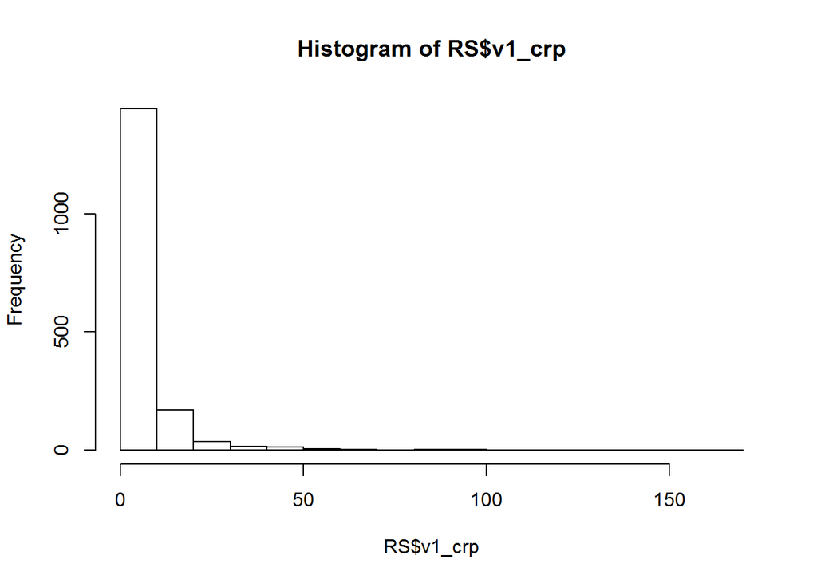

```r
#Visualization
#CRP
hist(RS$v1_crp)
```

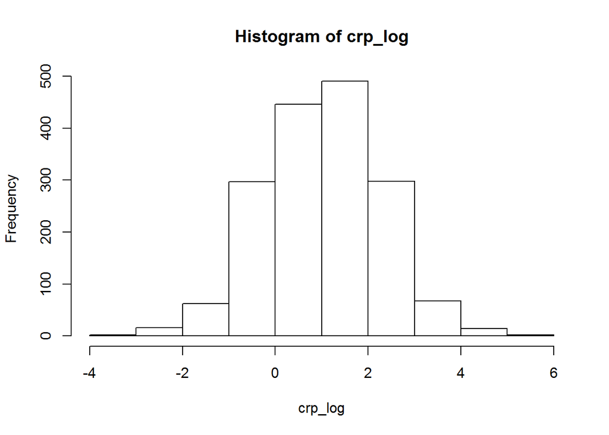

```r
#transform crp
crp_log<-log(RS$v1_crp)
hist(crp_log)
```

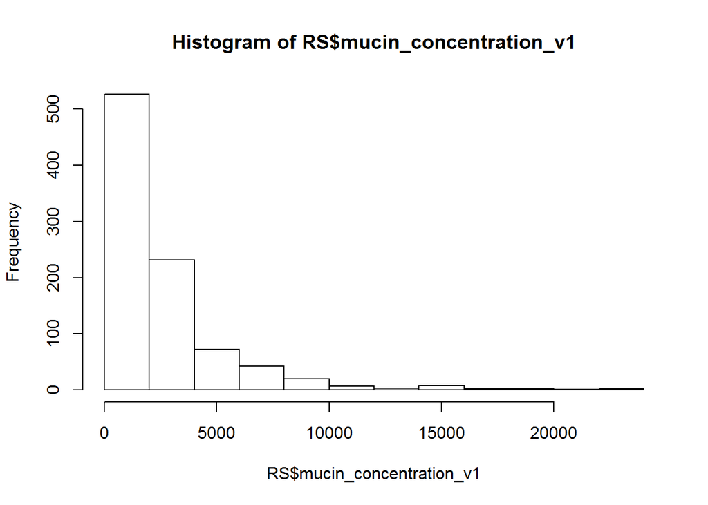

```r
#mucin concentration
hist(RS$mucin_concentration_v1)
```

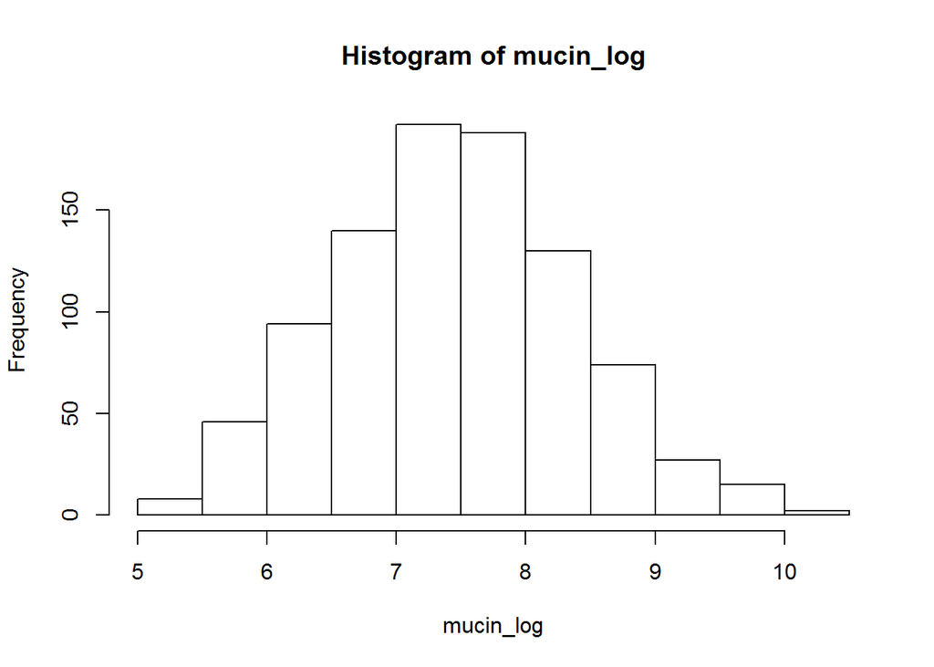

```r
#Transform mucin to logarithm scale
mucin_log<-log(RS$mucin_concentration_v1)
hist(mucin_log)
```

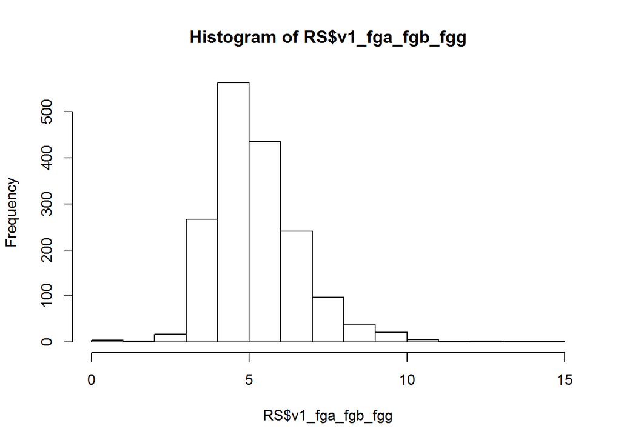

```r
#Fibrinogen
hist(RS$v1_fga_fgb_fgg)
```

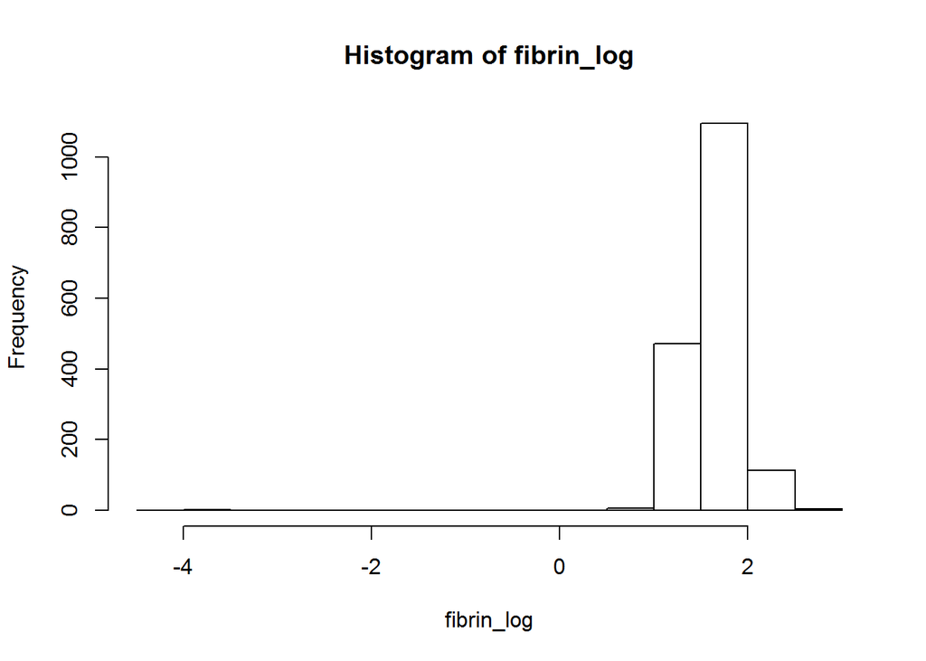

```r
#Transform fibrinogen to logarithm scale
fibrin_log<-log(RS$v1_fga_fgb_fgg)
hist(fibrin_log)
```

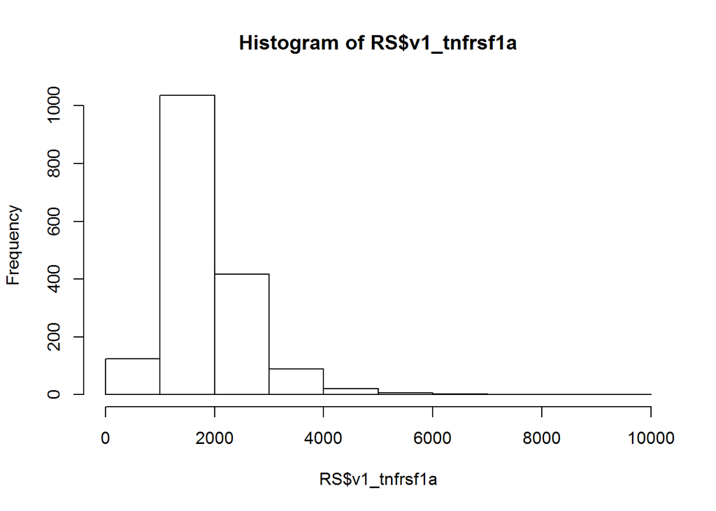

```r
#Soluble TNFa-1
hist(RS$v1_tnfrsf1a)
```

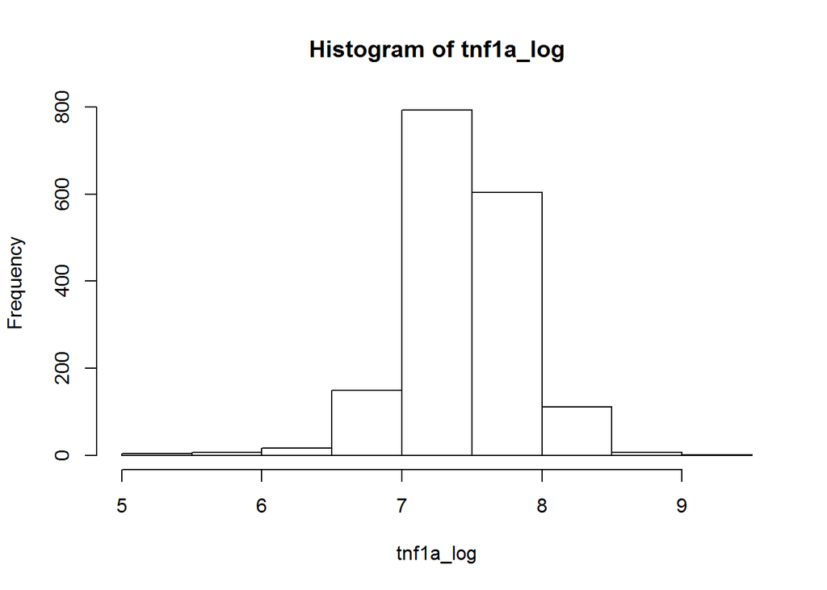

```r
#Transform TNFa-1
tnf1a_log<-log(RS$v1_tnfrsf1a)
hist(tnf1a_log)
```

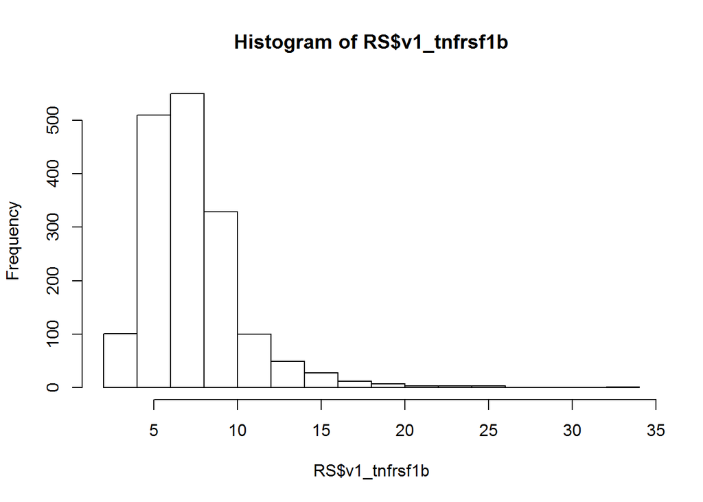

```r
#Soluble TNFb-1
hist(RS$v1_tnfrsf1b)
```

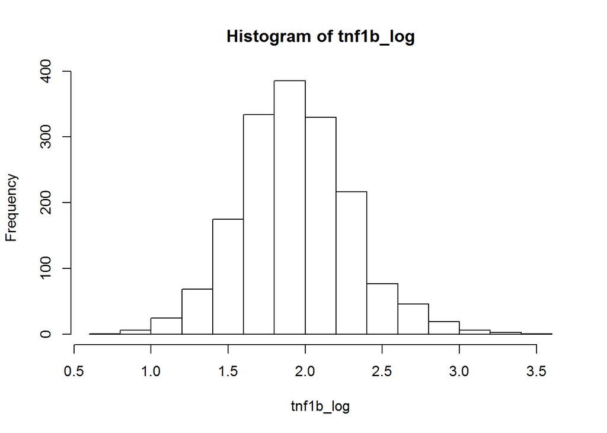

```r
#Transform TNFa-1
tnf1b_log<-log(RS$v1_tnfrsf1b)
hist(tnf1b_log)
```

```r
#Heatmap of variables
RS_matrix<-data.matrix(RS[,c("v1_crp","mucin_concentration_v1","v1_fga_fgb_fgg", "v1_tnfrsf1a", "v1_tnfrsf1b")])
```

# heatmap

```r
mydistfunPearson = function(x) {
  t.dist = 1 - cor(t(x), use="pairwise")
  t.limit <- 1.1*max(t.dist,na.rm=TRUE)
  t.dist[is.na(t.dist)] = t.limit
  t.dist = as.dist(t.dist)
  return(t.dist)
}

mydistfunEuc = function(x) {
  t.dist = dist(x)
  t.limit <- 1.1*max(t.dist,na.rm=TRUE)
  t.dist[is.na(t.dist)] = t.limit
  return(t.dist)
}

# EITHER
# standardize (mean center and scale by standard deviation) the data across each gene, so that genes with high expression don't outweigh genes with low expression
RS_matrix = t(scale(RS_matrix))


# Get max/min 90% of data for the color lookup table that will be used to color the individual blocks of the heatmap. Basically, doing this so outliers don't set the color limits leading to most things in between looking the same.
x = as.vector(RS_matrix)
z = (x-mean(x,na.rm=TRUE)) / sd(x,na.rm=TRUE)
rm.index = which(pnorm(abs(z), lower.tail=FALSE) < 0.05)
x[rm.index] = NA
maxvalue = max(x,na.rm=TRUE)
minvalue = min(x,na.rm=TRUE)
```

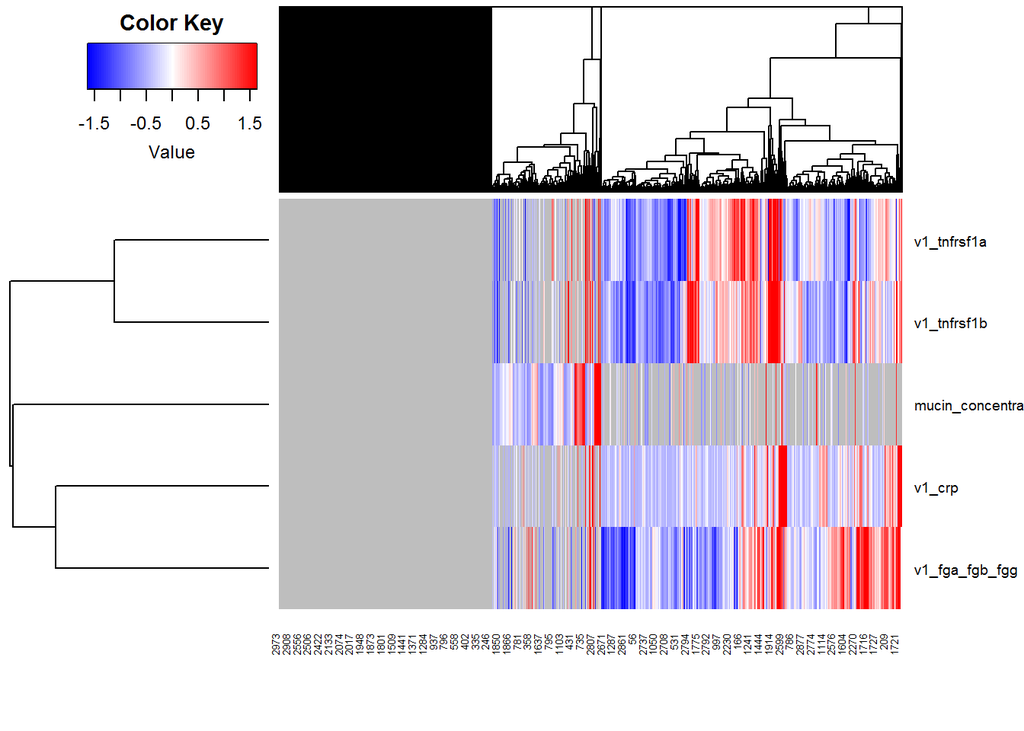

```r
#Finally, use the heatmap.2 function from the gplots package. Change "average" to "complete" for complete linkage, and change mydistfunPearson to mydistfunEuc for Euclidean distance. I find that the two different distance functions highlight different aspects of the data, with the Euclidean distance metric tending to put outlier samples into their own polarized branch.
library(gplots)
heatmap.2(RS_matrix,distfun=mydistfunEuc,hclustfun=function(x) hclust(x,method="complete"),cexRow=0.7,breaks=seq(minvalue,maxvalue,length.out=76),col=bluered(75),na.color="grey",offsetRow=0,trace="none",density.info="none")
```

```r
#Data Summary
tapply(X=RS$age_derv_v1, INDEX=RS$resmoke, FUN=mean)
```

```
##        0        1        2        3        4        5
## 56.45050 60.39080 60.23256 66.50498 65.10854 64.29213
```

```r
tapply(X=RS$smoking_pack_years_v1, INDEX=RS$resmoke, FUN=mean, na.rm=TRUE)
```

```
##            0            1            2            3            4
##  0.007276119 38.467241374 45.155852719 50.351156716 53.988583642
##            5
## 52.412632422
```

```r
#Average # of cigarettes smoke/day
tapply(X=RS$rds32_v1, INDEX=RS$resmoke, FUN=mean,na.rm=TRUE)
```

```
##        0        1        2        3        4        5
##  5.50000 23.06433 24.52838 25.68798 26.00750 26.66777
```

```r
#Age started smoking
tapply(X=RS$rds28_v1, INDEX=RS$resmoke, FUN=mean, na.rm=TRUE)
```

```
##        0        1        2        3        4        5
## 15.50000 17.22414 16.57171 16.66327 16.51114 16.73159
```

```r
#Age stopped smoking
tapply(X=RS$rds31_v1, INDEX=RS$resmoke, FUN=mean, na.rm=TRUE)
```

```
##        0        1        2        3        4        5
## 17.00000 49.18750 52.22176 54.78346 56.07219 55.85398
```

```r
#Spirometry data
tapply(X=RS$pct_post_fev1_v1, INDEX=RS$resmoke, FUN=mean, na.rm=TRUE)
```

```
##         0         1         2         3         4         5
## 101.81522 100.61183  96.48042  92.21551  65.11707  35.26754
```

```r
tapply(X=RS$pct_post_fev1fvc_v1, INDEX=RS$resmoke, FUN=mean, na.rm=TRUE)
```

```
##         0         1         2         3         4         5
## 102.74762 101.79384  99.11076  83.86792  73.22325  49.31632
```